# Stock Data Analysis: RSI to Returns Conversion

Deepika Dokuru

### Introduction

This project aims to analyze historical stock data for Apple Inc. (AAPL) using various technical indicators and machine learning models. The objective is to predict future returns based on the Relative Strength Index (RSI) and other key indicators derived from the stock price and volume data.

### Data Collection and Exploration

To begin, we collected stock data for AAPL from Yahoo Finance using the quantmod package. The exploratory data analysis phase involved examining the structure and characteristics of the dataset. We inspected the head, tail, and summary statistics of the data to gain insights into its distribution and variability.

```r
# Load necessary libraries
library(quantmod)
library(xts)
library(TTR)
library(PerformanceAnalytics)
library(caret)
library(Metrics)
```

```r
library(ggplot2)
library(stats)
library(psych)
# Get Stock data
getSymbols("AAPL", src = "yahoo")
```

```
## [1] "AAPL"
```

```r
# Exploratory Data Analysis
head(AAPL)
```

```
##            AAPL.Open AAPL.High AAPL.Low AAPL.Close AAPL.Volume AAPL.Adjusted
## 2007-01-03  3.081786  3.092143 2.925000   2.992857  1238319600      2.530319
## 2007-01-04  3.001786  3.069643 2.993571   3.059286   847260400      2.586481
## 2007-01-05  3.063214  3.078571 3.014286   3.037500   834741600      2.568063
## 2007-01-08  3.070000  3.090357 3.045714   3.052500   797106800      2.580745
## 2007-01-09  3.087500  3.320714 3.041071   3.306071  3349298400      2.795126
## 2007-01-10  3.383929  3.492857 3.337500   3.464286  2952880000      2.928891
```

```r
tail(AAPL)
```

```
##            AAPL.Open AAPL.High AAPL.Low AAPL.Close AAPL.Volume AAPL.Adjusted
## 2024-05-16    190.47    191.10   189.66     189.84    52845200        189.84
## 2024-05-17    189.51    190.81   189.18     189.87    41282900        189.87
## 2024-05-20    189.33    191.92   189.01     191.04    44361300        191.04
## 2024-05-21    191.09    192.73   190.92     192.35    42309400        192.35
## 2024-05-22    192.27    192.82   190.27     190.90    34648500        190.90
## 2024-05-23    190.98    191.00   186.63     186.88    50944900        186.88
```

```r
summary(AAPL)
```

```
##      Index              AAPL.Open         AAPL.High          AAPL.Low
##  Min.   :2007-01-03   Min.   :  2.835   Min.   :  2.929   Min.   :  2.793
##  1st Qu.:2011-05-06   1st Qu.: 12.377   1st Qu.: 12.491   1st Qu.: 12.315
##  Median :2015-09-12   Median : 27.494   Median : 27.769   Median : 27.200
##  Mean   :2015-09-12   Mean   : 53.138   Mean   : 53.703   Mean   : 52.594
##  3rd Qu.:2020-01-16   3rd Qu.: 67.650   3rd Qu.: 69.434   3rd Qu.: 66.829
##  Max.   :2024-05-23   Max.   :198.020   Max.   :199.620   Max.   :197.000
##    AAPL.Close       AAPL.Volume        AAPL.Adjusted
##  Min.   :  2.793   Min.   :2.405e+07   Min.   :  2.361
##  1st Qu.: 12.384   1st Qu.:9.894e+07   1st Qu.: 10.470
##  Median : 27.451   Median :1.963e+08   Median : 25.015
##  Mean   : 53.171   Mean   :3.508e+08   Mean   : 51.296
##  3rd Qu.: 68.333   3rd Qu.:4.762e+08   3rd Qu.: 66.555
##  Max.   :198.110   Max.   :3.373e+09   Max.   :197.590
```

### Technical Indicators Calculation

We calculated several technical indicators commonly used in financial analysis, including the 20-day Simple Moving Average (SMA20), RSI, Moving Average Convergence Divergence (MACD), On-Balance Volume (OBV), and Average True Range (ATR). These indicators provide valuable insights into price trends, momentum, volatility, and trading volume dynamics in the stock market.

```r
# Some Indicators
AAPL$SMA20 <- SMA(AAPL$AAPL.Close, n = 20)
AAPL$RSI <- RSI(AAPL$AAPL.Close)
AAPL$MACD <- MACD(AAPL$AAPL.Close)
AAPL$OBV <- OBV(AAPL$AAPL.Close, AAPL$AAPL.Volume)
AAPL$ATR <- ATR(AAPL[, c("AAPL.High", "AAPL.Low", "AAPL.Close")])
```

### Visualization

Using the ggplot2 package, we visualized the calculated technical indicators to gain a deeper understanding of AAPL’s historical performance. Line charts were created to visualize the trends in SMA20, RSI, and MACD over time. Additionally, we plotted AAPL’s stock prices to visualize its historical price movements and identify potential patterns or trends.

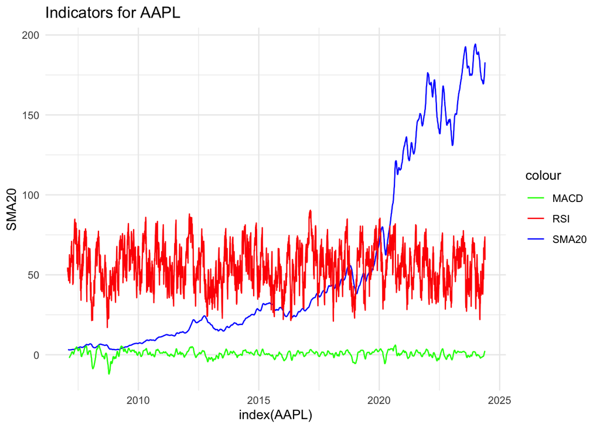

```r
# Visualization
library(ggplot2)

ggplot(data = AAPL, aes(x = index(AAPL))) +
  geom_line(aes(y = SMA20, color = "SMA20")) +
  geom_line(aes(y = RSI, color = "RSI")) +
  geom_line(aes(y = MACD, color = "MACD")) +
  labs(title = "Indicators for AAPL") +
  scale_color_manual(values = c("SMA20" = "blue", "RSI" = "red", "MACD" = "green")) +
  theme_minimal()
```

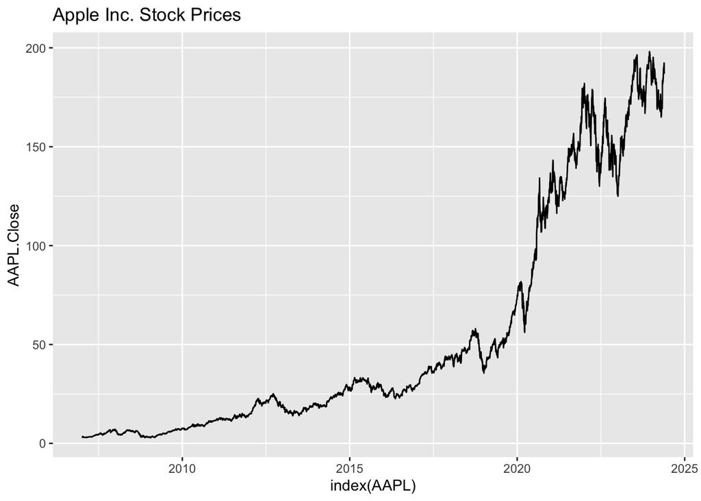

```r
ggplot(data = AAPL, aes(x = index(AAPL), y = AAPL.Close)) +
  geom_line() +
  labs(title = "Apple Inc. Stock Prices")
```

### Conversion of RSI to Returns

One of the key transformations performed in this analysis was the conversion of RSI values to returns. This was achieved using the ROC function from the TTR package. By calculating the discrete rate of change in RSI values over time, we obtained a measure of the percentage change in market momentum, which can be indicative of potential shifts in stock returns.

```r
# Convert RSI to returns
library(TTR)
AAPL$RSI_returns <- ROC(AAPL$RSI, type = "discrete", na.pad = FALSE)
```

### Performance Evaluation and Model Development

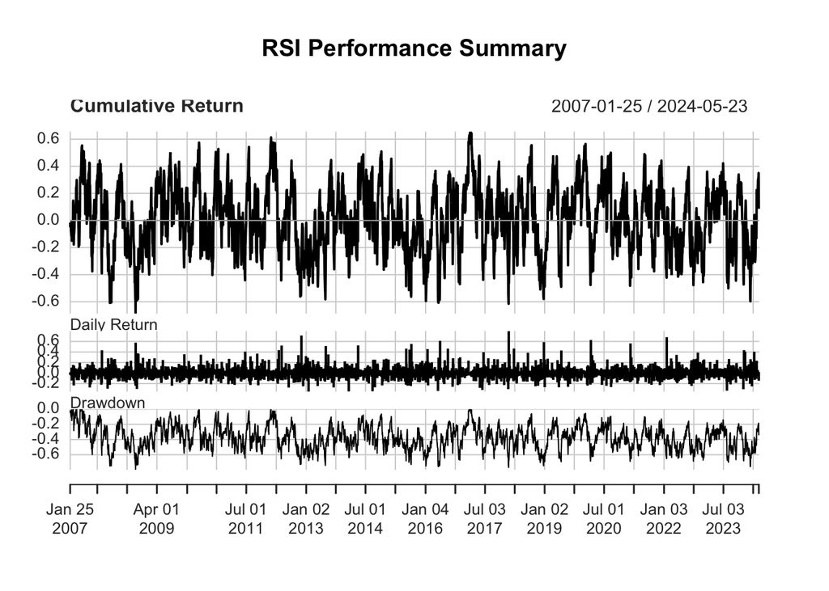

```r
# Plot performance summary
library(PerformanceAnalytics)
charts.PerformanceSummary(AAPL$RSI_returns, main = "RSI Performance Summary")
```

```r
# Remove missing values
data <- na.omit(AAPL)

#Split data into training and testing sets
set.seed(123) # for reproducibility
train_index <- createDataPartition(data$RSI_returns, p = 0.8, list = FALSE)
train_subset <- data[train_index, ]
test_subset <- data[-train_index, ]

# Train linear regression model
model <- lm(RSI_returns ~ AAPL.Open + SMA20 + RSI + MACD + ATR + macd + tr , data = train_subset)
summary(model)
```

```
##
## Call:
## lm(formula = RSI_returns ~ AAPL.Open + SMA20 + RSI + MACD + ATR +
##     macd + tr, data = train_subset)
##
## Residuals:
##      Min       1Q   Median       3Q      Max
## -0.45247 -0.04540 -0.00504  0.03788  0.75849
##
## Coefficients:
##               Estimate Std. Error t value Pr(>|t|)
## (Intercept) -0.2918174  0.0124007 -23.532  < 2e-16 ***
## AAPL.Open   -0.0341763  0.0025177 -13.574  < 2e-16 ***
## SMA20        0.0028004  0.0006116   4.579 4.84e-06 ***
## RSI          0.0056008  0.0002282  24.542  < 2e-16 ***
## MACD         0.0207363  0.0029113   7.123 1.28e-12 ***
## ATR          0.0313088  0.0025702  12.181  < 2e-16 ***
## macd        -0.0462195  0.0033693 -13.718  < 2e-16 ***
## tr           0.0204830  0.0020006  10.239  < 2e-16 ***
## ---
## Signif. codes:  0 '***' 0.001 '**' 0.01 '*' 0.05 '.' 0.1 ' ' 1
##
## Residual standard error: 0.08467 on 3469 degrees of freedom
## Multiple R-squared:  0.2192, Adjusted R-squared:  0.2177
## F-statistic: 139.2 on 7 and 3469 DF,  p-value: < 2.2e-16
```

```r
# Make predictions on test data
predictions <- predict(model, newdata = test_subset)
r_squared <- R2(predictions, test_subset$RSI_returns)
mae <- MAE(predictions, test_subset$RSI_returns)
mse <- mse(predictions, test_subset$RSI_returns)
rmse <- RMSE(predictions, test_subset$RSI_returns)

cat("R-squared:", r_squared, "\n")
```

```
## R-squared: 0.2364101
```

```r
cat("Mean Absolute Error (MAE):", mae, "\n")
```

```
## Mean Absolute Error (MAE): 0.06086154
```

```r
cat("Mean Squared Error (MSE):", mse, "\n")
```

```
## Mean Squared Error (MSE): 0.007693251
```

```r
cat("Root Mean Squared Error (RMSE):", rmse, "\n")
```

```
## Root Mean Squared Error (RMSE): 0.08771118
```

### Residual Analysis and Cross-Validation

I analyzed the residuals of the regression model to assess its predictive performance and conducted cross-validation to validate the model’s robustness. Furthermore, I compared the model’s performance against a baseline model predicting the mean returns.

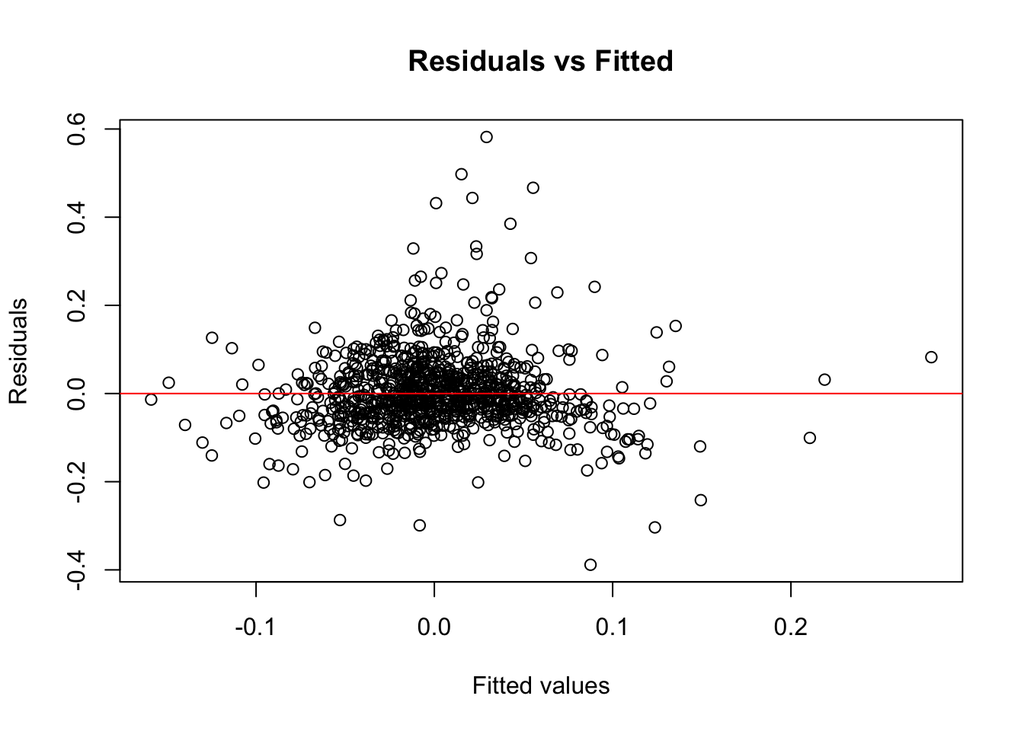

```r
# Analyzing the Residual
residuals <- test_subset$RSI_returns - predictions
plot(predictions, residuals, main = "Residuals vs Fitted", xlab = "Fitted values", ylab = "Residuals")
abline(h = 0, col = "red")
```

```r
# Conducting a Cross-Validation
cv_results <- train(
  RSI_returns ~ AAPL.Open + SMA20 + RSI + MACD + ATR + macd + tr,
  data = train_subset,
  method = "lm",
  trControl = trainControl(method = "cv", number = 10)
)
print(cv_results)
```

```
## Linear Regression
##
## 3477 samples
##    7 predictor
##
## No pre-processing
## Resampling: Cross-Validated (10 fold)
## Summary of sample sizes: 3130, 3129, 3130, 3129, 3129, 3129, ...
## Resampling results:
##
##   RMSE        Rsquared   MAE
##   0.08472529  0.2170282  0.05873195
##
## Tuning parameter 'intercept' was held constant at a value of TRUE
```

```r
baseline_model <- lm(RSI_returns ~ 1, data = train_subset) # Simple baseline model (predicting mean)
baseline_predictions <- predict(baseline_model, newdata = test_subset)
baseline_mae <- MAE(baseline_predictions, test_subset$RSI_returns)

cat("Baseline MAE:", baseline_mae, "\n")
```

```
## Baseline MAE: 0.07020754
```

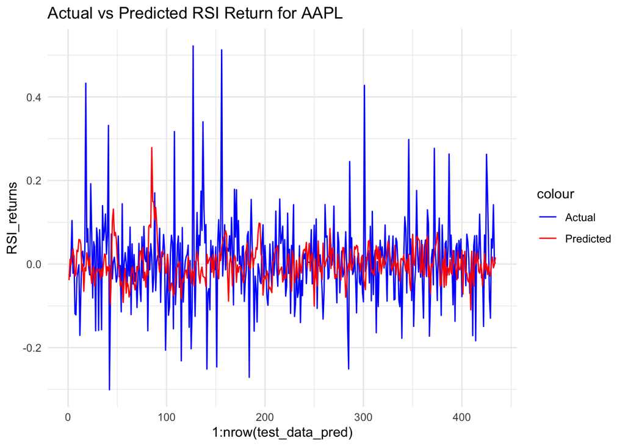

```r
#Visualize
test_data_pred<-cbind(predictions, test_subset)
test_data_pred<-na.omit(test_data_pred)
ggplot(data = test_data_pred, aes(x = 1:nrow(test_data_pred))) +
  geom_line(aes(y = RSI_returns, color = "Actual")) +
  geom_line(aes(y = predictions, color = "Predicted")) +
  labs(title = "Actual vs Predicted RSI Return for AAPL") +
  scale_color_manual(values = c("Actual" = "blue", "Predicted" = "red")) +
  theme_minimal()
```